# Standardized beta coefficients

Dan McGlinn

This mini-lesson is to introduce the concept of standardized regression coefficients in R. A standardized regression coefficient is simply the beta estimate from a regression on standardized variables. A standardized variable is a variable that has a mean of 0 and a standard deviation of 1.

One reason for standardizing variables is that you can interpret the beta estimates as partial correlation coefficients. In other words now that the variables are standardized you can compare how correlated they are to the response variable using their regression coefficients. Below is a demo of this.

```r
## We will use this function to plot the data and correlations
panel.cor <- function(x, y, digits = 2, prefix = "", cex.cor=3, ...)
{
    usr <- par("usr"); on.exit(par(usr))
    par(usr = c(0, 1, 0, 1))
    r <- abs(cor(x, y))
    txt <- format(c(r, 0.123456789), digits = digits)[1]
    txt <- paste0(prefix, txt)
    if(missing(cex.cor))
        cex.cor <- 0.8/strwidth(txt)
    text(0.5, 0.5, txt, cex = cex.cor)
}
```

Simulate some data for running models. Here to provide a clear demonstration we need explanatory variables that are independent normal variates.

```r
set.seed(10)
n = 90
x1 = rnorm(n)
x2 = rnorm(n)
x3 = rnorm(n)

#organize predictors in data frame
sim_data = data.frame(x1, x2, x3)
#create noise b/c there is always error in real life
epsilon = rnorm(n, 0, 3)
#generate response: additive model plus noise, intercept=0
sim_data$y = 2*x1 + x2 + 3*x3 + epsilon
```

Before standardizing variables it is worthwhile to highlight that the relationship between correlation and regression statistics. Specifically, the t-statistic from a simple correlation coefficient is exactly what is reported for the beta_1 coefficient in a regression model.

```r
cor.test(sim_data$y, sim_data$x1)$statistic
```

```
##       t
## 3.28821
```

```r
summary(lm(y ~ x1, data=sim_data))$coef
```

```
##              Estimate Std. Error  t value    Pr(>|t|)
## (Intercept) 0.5675109  0.5015436 1.131529 0.260906812
## x1          1.7411233  0.5295049 3.288210 0.001450304
```

The beta coefficient reported by the regression is not equal to the correlation coefficient though because the beta is in the units of the x1 variable (i.e., it has not been standardized). Now let’s use the function `scale()` to standardize the independent and dependent variables.

```r
sim_data_std = data.frame(scale(sim_data))

mod = lm(y  ~ x1 + x2 + x3, data=sim_data)
mod_std = lm(y  ~ x1 + x2 + x3, data=sim_data_std)
round(summary(mod)$coef, 3)
```

```
##             Estimate Std. Error t value Pr(>|t|)
## (Intercept)    1.089      0.320   3.400    0.001
## x1             2.071      0.336   6.161    0.000
## x2             1.089      0.327   3.327    0.001
## x3             3.580      0.323  11.076    0.000
```

```r
round(summary(mod_std)$coef, 3)
```

```
##             Estimate Std. Error t value Pr(>|t|)
## (Intercept)    0.000      0.063   0.000    1.000
## x1             0.393      0.064   6.161    0.000
## x2             0.212      0.064   3.327    0.001
## x3             0.707      0.064  11.076    0.000
```

```r
cor(sim_data$y, sim_data$x1)
```

```
## [1] 0.3307912
```

```r
cor(sim_data$y, sim_data$x2)
```

```
## [1] 0.2037518
```

```r
cor(sim_data$y, sim_data$x3)
```

```
## [1] 0.6772098
```

Notice that above the t-statistics and consequently the p-values between `mod` and `mod_std` don’t change (with the exception of the intercept term which is always 0 in a regression of standardized variables). This is because the t-statistic is a pivotal statistic meaning that its value doesn’t depend on the scale of the difference.

Additionally notice that the individual correlation coefficients are very similar to the beta estimates in `mod_std`. Why are these not exactly the same? Here’s a hint - what would happen if their was strong multicollinarity between the explanatory variables?

Let’s plot the variables against one another and also display their individual Pearson correlation coefficients to get a visual perspective on the problem

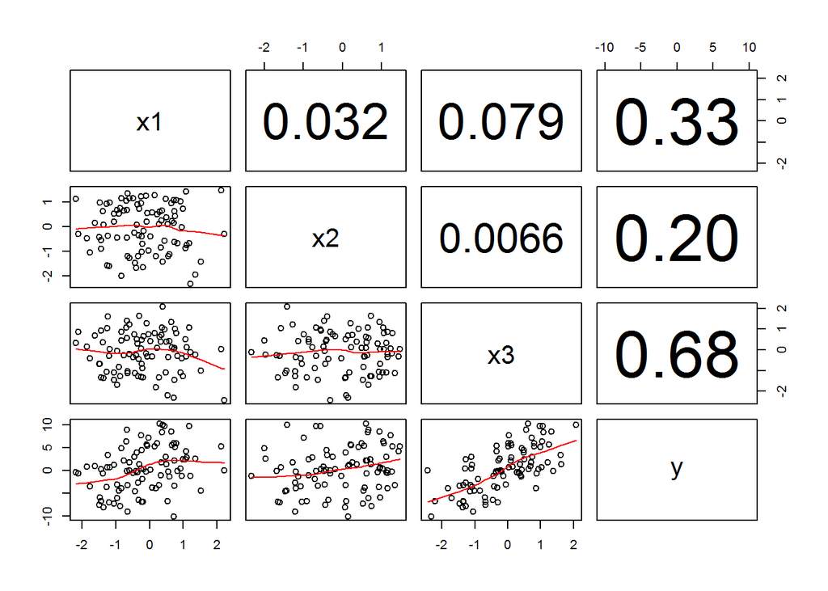

```r
pairs(sim_data, lower.panel = panel.smooth, upper.panel = panel.cor)
```